# 2.04-Singly-Linked-Lists

##### Time : *O* (1)

##### Space : *O* (1)

### Pop Left

- Pop Left = remove the first element (the head) of the list and return its value.
- It’s called “left” because if you visualize the list as a sequence (like [head → ... → tail]), the head is on the left side.
- After popping, the head pointer moves to the next node.

**BEFORE POP**

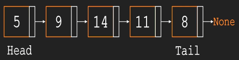

**AFTER POP**

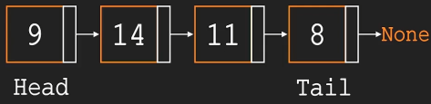

The trick here is to reassign the head value before we remove the head. So first we need to save the current head in a variable. And then we can just move the head attribute to the next element that comes after five. After that, make the old head point to nothing and that would remove it. So once again the steps are.

- Save the head in a new variable.
- Move the head of the list to the next node.
- Then make the old head we have stored in the variable point to none.

```python
# This method removes the first node(head) of the list and returns its value
def pop_left(self): # No  parameter is needed because we’re not adding anything, only removing.
    if not self._length:
        raise Exception("List is Empty") # If the list is empty, we cannot pop anything.Raises an exception to signal the error.
    former_head = self.head # Stores the current head node in a temp variable, so we can return its value later.This is the node we’re about to remove
    self.head = former_head.next # Moves the head pointer to the next node.Effectively removes the old head from the chain.
# If there was only one node, former_head.next is None, so head becomes None
    former_head.next = None # Breaks the link from the removed node to the rest of the list.
    self._length -= 1
    if not self._length: # Checks again if the list is now empty (after removal).This happens if we just removed the only node
        self.tail = None #If the list is empty, set tail to None as well. Ensures both head and tail are None when the list has no nodes.
    return former_head.value # Returns the value stored in the removed node.This is the “pop” result, just like list.pop(0) in Python’s built-in list.
```

**Why Add the Exception Error?**

If we have an empty list and we call this pop left. We want some kind of response back that tells us there is no element in the list. Now, there are a couple of ways we can handle this, one of which would be to just return none. But I don't think it's the best approach, because if I call pop left on an empty list and I get back none, I might think that the operation was successful and that there was actually a node to be removed. A better solution, in my opinion, would be to throw an error message. So if the length is zero, we can just raise an exception with the message. Something like list is empty. And now we get a more correct response back.

We now know the list was empty and there was no element to remove. Now I want to mention that raising this type of custom error messages is not always mandatory, and most learning materials usually leave them out. But I personally like them, and I think it creates a good habit of thinking about all the possible scenarios you could encounter.

**Why append / prepend return self**

- These methods add a new node to the list.
- Returning self allows method chaining:

mylist.append(10).append(20).prepend(5)

- You don’t care about the new node itself — you care about the updated list.
- So returning the list object (self) makes sense.

**Why pop_left returns former_head.value**

- pop_left removes a node.
- The important result is the value that was removed, not the updated list.
- Example:

val = mylist.pop_left() print(val) # shows the removed value

- If it returned self, you’d lose the information about which element was popped.
- Returning the node’s value is consistent with Python’s built-in list.pop(), which also returns the removed element.

**Analogy**

Think of a vending machine:

- Append/Prepend → you’re loading snacks into the machine. You want to keep interacting with the machine itself (so return self).
- Pop Left → you’re taking a snack out. You don’t care about the machine object at that moment — you care about the snack (so return the value).

✅ So:

- Mutator methods (append/prepend) → return self for chaining.
- Removal methods (pop_left) → return the removed value, because that’s the useful result.

```python
my_list = SinglyLinkedList()
```

```python
# Starting from Scratch again.
print(my_list.head)
print(my_list.tail)
print(my_list._length)
```

```
None
None
0
```

```python
# Updating the same numbers in Before & After snapshot using method chaining
my_list.append(5).append(9).append(14).append(11).append(8)
```

```
<__main__.SinglyLinkedList at 0x1d810cb58b0>
```

```python
# Verifying the output
print(my_list.head)
print(my_list.tail)
print(my_list._length)
# This is what you get whem the list is not empty
```

```
<__main__.Node object at 0x000001D8133B59A0>
<__main__.Node object at 0x000001D8133EF920>
5
```

```python
# We will refine the print command for Singly linked list [5,9,14,11,8]
print(my_list.head.value)
print(my_list.tail.value)
print(my_list._length)
```

```
5
8
5
```

```python
# Now lets Pop Left 5 from the list
my_list.pop_left()
```

```
5
```

#### Time And Space Complexity

A Pop Left method removes the first element from a list. So in terms of how many operations it performs, does the size make a difference here? No. We do the same number of operations regardless of how many items we have. And when we talk about memory consumption, we only create one new variable the former head, no matter the length of the list. So both the number of operations and the memory usage are the same, regardless of the size of the list. Therefore, both complexities are O(1).

##### Time : *O* (1)

##### Space : *O* (1)

### Pop Right

If pop left was the name of the function that removed the first element. Pop right will remove the last one.

**BEFORE POP RIGHT**

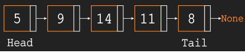

**AFTER POP RIGHT**

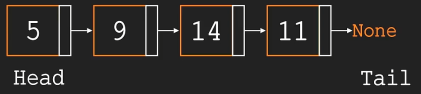

So if we want to remove the tail, we must make 11 point to none instead of to the eight node. That sounds pretty simple, right? But let me ask you this. How do we access the second to last node?

We know that we have access to the last node using the tail attribute, but the tail doesn't have access to its preceding element. In fact, none of our elements do. Recall that a node object only carries a pointer to the next item. So if we take the node eight as an example, all it knows is that it carries a value and its next attribute is none It doesn't know who is pointing to it. Who is the preceding node? So how do we access the second to last node then?

The steps for this method would be like this. Loop through all the nodes starting from the head of the list, checking if each node points to the tail, and when you find the one that does have it, point to none instead. And then make that node the new tail. But also be mindful of the special cases and the extra bits of work, like decreasing the length and what value you should return.

```python
def pop_right(self): # pop_right mirrors Python’s list.pop() but specifically from the right end
    if not self._length: # self._length tracks the number of nodes. If _length == 0, the list is empty → popping is invalid.
        raise Exception("List is empty") # Raising an Exception prevents undefined behavior
    tail_value = self.tail.value # Before modifying the list,save the value of the last node.This way we can return it later,even after removing the node
    if self._length == 1:# If there’s only one node: Both head & tail point to the same node.Removing it means the list becomes empty → set both to None.
        self.head = self.tail = None # This is a base case that avoids traversing unnecessarily.
    else : # General Case (More than One Node)
        temp_node = self.head # Start from the head to find the second-to-last node.
        while temp_node.next is not self.tail: # Traverse Until Node Before Tail.Walk through the list until temp_node.next points to the current tail.
            temp_node = temp_node.next # This loop stops at the node just before the tail.
        self.tail = temp_node # Update Tail Reference - Now temp_node becomes the new tail.
        self.tail.next = None # Break Link to Old Tail - Disconnect the old tail node.Ensures the list ends cleanly at the new tail.
    self._length -= 1 # Decrement the length counter to reflect removal, Maintaining _length is crucial for O(1) size checks
    return tail_value # Finally, return the value of the removed node. This matches Python’s list.pop() behavior.
```

```python
# we have list elenents [5,9,14,11,8] as discussed in above snapshots. lets review current status
print(my_list.head.value)
print(my_list.tail.value)
print(my_list._length)
```

[output not shown]

```python
# Pop_right function is now available from dropdown option when using the object(my_list)Now we will pop_right(8) from the list & should get(8)as return
my_list.pop_right()
```

```
8
```

```python
# Lets review the list after pop_right
print(my_list.head.value)
print(my_list.tail.value)
print(my_list._length)
```

[output not shown]

#### Time And Space Complexity

In terms of running time. Does anything change when our list starts growing? Do we do the same number of operations regardless of its size If you remember any loop, whether it's a for loop or a while, should raise a flag when you think about the runtime of a function. And this is a prime example of that If we have a list of 1 million items, this **while loop** will reassign the temp node over and over again until it reaches the end, meaning it will do a million more operations compared to a list of one item. So the running time of our function does depend on the size of the list. It's even directly proportional to it, meaning that the time complexity is O(n).

What about the space complexity We need to ask ourselves the same question. Does memory usage increase in the same way? You might be inclined to say yes, since inside the loop we assign some value to a variable multiple times with each iteration. But keep in mind we never use additional memory for that. We only allocate memory once for that variable, and then we essentially replace it with a new one. We don't keep the old values because of that. The memory complexity is constant. Therefore O(1).

##### Time : *O* (n)

##### Space : *O* (1)

### Remove

Earlier we were moving from fixed positions and we were returning the values that were inside the nodes. But let's now have a look at a different approach. Let's say that this time we want to remove a node whose value we know beforehand. This node can potentially be anywhere in the list at the end, at the beginning, or anywhere in between. And unlike the pop left or pop right functions, this time we might not have direct access to it. In most cases, we wouldn't even know where it's located.

So let's have a look at our list. We have here and say that we want to remove the node with the value 11.That means we should make it its preceding node, which is 14 pointing to whatever 11 is pointing to, which in our case is the eight node. And now, since there is no other node pointing to it, 11 will be removed from the list. So that's what the end result would look like

**BEFORE REMOVE (11)**

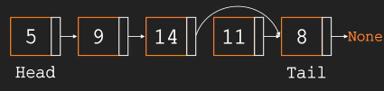

**AFTER REMOVE**

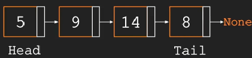

Let's assume we want to remove the number 11 from the list. When we provide the value 11 as a parameter, Python will save that in a variable and then run the code as usual from top to bottom, checking the length (if the list is empty), then checking the first node (if match then run pop_left). And since none of these conditions are met, we now create the previous and current node variables. We then enter the while loop.

At this point, current node ended up being 11, which is the one we're looking for, so the loop stops ,after we break out. We check again. Did we break because we reached the end? In this case, no. So we moved to the next condition, is our current node The tail ? is its next attribute None ?. No, it's the 8 node. So then we proceed to remove the element we found. We point the previous node to the current node's next node. In our example point 14 to 8. And then make the current node point to none instead of 8. And finally the last two lines run after that, decreasing the length and returning the value we removed. And that's it

One last thing I want to mention about our function because of how we built the while loop. Our function will only remove the first node it finds with the target value. So if we were to have two nodes that contain the number 14, for example, we don't remove both of them, only the first one, and then the execution stops. This is, however, not something unusual in most programming languages. Methods that remove elements based on a specified value stop when they find the first occurrence, and our version is therefore compliant with this general rule.

```python
def remove(self, value):# Purpose: find the node containing "Value", remove it from the list, and return its value.
    if not self._length:# If _length==0,the list has no nodes.Trying to remove from an empty list is invalid → raise an exception.
        raise Exception("List is Empty")# Best practice: use "ValueError("List is empty")" or "IndexError" for consistency with Python’s built-ins.
    if self.head.value == value: # If the value is in the head node, remove it using "pop_left"(your existing method).
        return self.pop_left()# This avoids duplicating logic for head removal.Design choice: reuse existing methods for consistency and maintainability.
    previous_node = self.head # previous_node tracks the node before current_node
    current_node = self.head.next # Start traversal from the second node (head.next). This setup allows you to "unlink" the target node when found
# Traverse Until Value Found. Loop through nodes until a) You reach the end (current_node is None), OR b) You find the node with the matching value
    while current_node is not None and current_node.value != value:
        previous_node = current_node # Each iteration: - Move previous_node forward to current_node and
        current_node = current_node.next # - Move current_node forward to the next node. This is the classic search loop in linked lists
    if current_node is None: # Value Not Found : - If traversal ends (current_node == None), the value doesn’t exist.
        raise ValueError("Item not in the list") # - Raise ValueError to signal the item wasn’t found.
    if current_node.next is None: # Check If Tail Node : - If current_node.next is None, then current_node is the tail node.
        self.tail = previous_node
    previous_node.next = current_node.next # Unlink the Node : - Skip over the current_node by linking previous_node.next directly to current_node.next
    current_node.next = None # Disconnect Removed Node : Break the link from the removed node to the rest of the list
    self._length -= 1 # Decrement the list size counter, Keeps _length consistent with actual number of nodes.
    return current_node.value
```

```python
# we have list elenents [5,9,14,11,8] as discussed in above snapshots. lets review current status
print(my_list.head.value)
print(my_list.tail.value)
print(my_list._length)
```

[output not shown]

```python
# "remove" function is now available from dropdown option when using the object(my_list)Now we will remove(11) from the list & should get(11)as return
my_list.remove(11)
```

```
11
```

```python
# Lets review the list after remove(11)
print(my_list.head.value)
print(my_list.tail.value)
print(my_list._length)
```

[output not shown]

#### Time And Space Complexity

We can see that just like the last function we wrote, we also have to potentially iterate over the entire list until we find the desired element. So we again have an increase in the number of operations proportional to the size of the list.

As for the space complexity, we're only creating two variables, which we keep updating in the while loop with no extra memory usage. Basically, even if we have many conditional checks in this function, the two complexities are the same as for the pop right method.

O(n) for the time complexity because of the **loop** and O(1) for the space complexity.

##### Time : *O* (n)

##### Space : *O* (1)

### Reverse

**Reverse** means flipping the direction of the list so the last node becomes the first, and the first node becomes the last.

- Every node’s .next pointer is changed to point backward instead of forward.
- The head becomes the old tail, and the tail becomes the old head.
- It’s done by walking through the list and carefully reassigning links one by one.

👉 In one line: Reverse in SLL is the process of turning the list around so traversal goes in the opposite direction.

**BEFORE REVERSE**

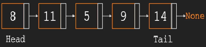

**AFTER REVERSE**

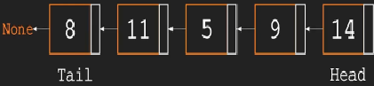

Imagine you have a chain of paper clips hooked together in a line, where each clip points to the next one. This algorithm flips the entire chain around so the last clip becomes first, and the first becomes last!

```python
def reverse(self): # - Purpose: reverse the order of nodes in the list so traversal goes in the opposite direction.
    if self._length < 2 : # If the list has fewer than 2 nodes (empty or single node), reversing doesn’t change anything.
        return self # Simply return the list itself. Efficiency note: avoids unnecessary looping.
# Set Up Three Helper Hands-
    left_node = None # 1.Left hand(left_node):Starts holding nothing (None) (L=None)
    middle_node = self.head#2.Middle hand (middle_node):Grabs the very first clip(the head) (M=08)
    while middle_node is not None :
        right_node = middle_node.next # 3.Right hand(right_node) grabs the next clip in the chain so you don't lose track of where to go next.
# (R=11),(R=11 to 05),(R=05 to 09),(R=09 to 14),(R=14 to None), R = None, breaks out of while loop
# This is where the actual reversal is happening, we are changing the direction of the pointer (from left to right "->" ) to right to left "<-"
        middle_node.next = left_node#Make the middle clip point backwards to the clip in your left hand(instead of forward).
# (M=None<- 08),(M=08<-11),(M=11<-05),(M=05<-09),(M=09<-14)
        left_node = middle_node # Your left hand moves up to grab what the middle hand was holding
# (L=None to 08),(L=8 to 11),(L=11 to 05),(L=05 to 09),(L=09 to 14)
        middle_node = right_node # Your middle hand moves to what the right hand was holding
# (M=8 to 11),(M=11 to 05),(M=05 to 09),(M=09 to 14),(M=14 to None)
# After the loop finishes, the chain is reversed, but the list still thinks the old first clip is the head.
# So we swap the labels: what was the tail is now the head, and vice versa!
    self.head, self.tail = self.tail, self.head # self.head (08), self.tail (14) = self.tail (08), self.head (14)
    return self
```

```python
# we have list elenents [8,11,5,9,14] as discussed in above snapshots. lets review current status
print(my_list.head.value)
print(my_list.tail.value)
print(my_list._length)
```

[output not shown]

```python
my_list.reverse()
```

```
<__main__.SinglyLinkedList at 0x26346a01b80>
```

```python
# Lets review the list after reverse
print(my_list.head.value)
print(my_list.tail.value)
print(my_list._length)
# Head has now changed from 8 to 14 and tail has changed from 14 to 8 while the length of the list remains the same (5)
```

```
14
8
5
```

#### Time And Space Complexity

In terms of runtime complexity, what can we expect from this solution? One thing should immediately stand out when analyzing this, and that is the while loop over all the nodes. Whenever we need to traverse an entire list, we can expect an O(n) running time, and our function is certainly not an exception. When it comes to the space complexity. As we already saw, we're reversing the list in place. We're not creating a new copy. The only thing we're doing is creating three variables, and we keep reassigning them inside the while loop. And we do the same thing regardless of the size of the list. Therefore, the memory utilization of our function will always be constant O(1)

##### Time : *O* (n)

##### Space : *O* (1)

### Final Algorithm

```python
class Node: # Creating a Node and initializing it with 2 containers (a.Value  b.Pointing to next node/ next pointer)
    def __init__(self, value):
        self.value = value # This will store the actual value
        self.next = None # this will store the pointer or points to next node it will be linking. For now its None (Node is empty)

class SinglyLinkedList: # Creating a new class to track pfirst(head) and last(tail) element of the List
    def __init__(self): # These are attributes (sometimes called instance variables).They hold values for head, tail & length
        self.head = None # We don't want to give them any starting values.We want the list to be empty when initialized
        self.tail = None # Both the head and the tail will eventually be some node objects we just defined up (in Node Class)
        self._length = 0 # Initial value is set to 0, we will increase and decrease it as we add or remove nodes
# The length is not mandatory, but it will make our lives easier with certain methods.And generally the length of a list is a pretty useful thing to know
# We'll define our append method inside the singly linked list class, so that we can call it on an instance of this class


    def append(self, value): # This is a method. It’s a behavior: it changes the state of the list by adding a new node
        new_node = Node(value) # Input value is assigned as "new_node" so we continue with next tasks like, updating tail, assigning tail ...etc
        if not self._length: # If the list is empty,the new node becomes both the head(first node)& the tail(last node).
            self.head = self.tail = new_node
        else :               # This initializes the linked list with its first element.
            self.tail.next = new_node  # If the list is not empty: then the pointer of tail(tail.next) is pointed towards new_node+
            self.tail = new_node # And the tail is also updated as "new_node"
        self._length += 1 # regardless of first node/entry or not length is updated for every entry(outside the loop)
        return self # Returns the linked list object itself (self). This allows method chaining* (e.g., mylist.append(10).append(20)



    def prepend(self, value): # Defines a method named inside the class. self refers to the current linked list object.
        new_node = Node(value)
        if not self._length: # Checks if the list is empty (_length == 0).
            self.head = self.tail = new_node#If the list is empty,both head & tail point to the new node since its simultaneously the first & last element.
        else : # Runs if the list is not empty.We need to insert the new node before the current head.
            new_node.next = self.head # Links the new node to the existing list.The new node’s next pointer now points to the old head.
            self.head = new_node # Updates the list’s head to the new node. Now the new node becomes the first element in the list.
        self._length += 1 # - Increases the length counter by 1.Keeps track of how many nodes are in the list.
        return self



    def pop_left(self): # No  parameter is needed because we’re not adding anything, only removing.
        if not self._length:
            raise Exception("List is Empty") # If the list is empty, we cannot pop anything.Raises an exception to signal the error.
        former_head = self.head # Stores the current head node in a temp variable, so we can return its value later.This is the node we’re about to remove
        self.head = former_head.next # Moves the head pointer to the next node.Effectively removes the old head from the chain.
    # If there was only one node, former_head.next is None, so head becomes None
        former_head.next = None # Breaks the link from the removed node to the rest of the list.
        self._length -= 1
        if not self._length: # Checks again if the list is now empty (after removal).This happens if we just removed the only node
            self.tail = None #If the list is empty, set tail to None as well. Ensures both head and tail are None when the list has no nodes.
        return former_head.value # Returns the value stored in the removed node.This is the “pop” result, just like list.pop(0) in Python’s built-in list.



    def pop_right(self): # pop_right mirrors Python’s list.pop() but specifically from the right end
        if not self._length: # self._length tracks the number of nodes. If _length == 0, the list is empty → popping is invalid.
            raise Exception("List is empty") # Raising an Exception prevents undefined behavior
        tail_value = self.tail.value # Before modifying the list,save the value of the last node.This way we can return it later,even after removing the node
        if self._length == 1:# If there’s only one node: Both head & tail point to the same node.Removing it means the list becomes empty → set both to None.
            self.head = self.tail = None # This is a base case that avoids traversing unnecessarily.
        else : # General Case (More than One Node)
            temp_node = self.head # Start from the head to find the second-to-last node.
            while temp_node.next is not self.tail: # Traverse Until Node Before Tail.Walk through the list until temp_node.next points to the current tail.
                temp_node = temp_node.next # This loop stops at the node just before the tail.
            self.tail = temp_node # Update Tail Reference - Now temp_node becomes the new tail.
            self.tail.next = None # Break Link to Old Tail - Disconnect the old tail node.Ensures the list ends cleanly at the new tail.
        self._length -= 1 # Decrement the length counter to reflect removal, Maintaining _length is crucial for O(1) size checks
        return tail_value # Finally, return the value of the removed node. This matches Python’s list.pop() behavior.



    def remove(self, value):# Purpose: find the node containing "Value", remove it from the list, and return its value.
        if not self._length:# If _length==0,the list has no nodes.Trying to remove from an empty list is invalid → raise an exception.
            raise Exception("List is Empty")# Best practice: use "ValueError("List is empty")" or "IndexError" for consistency with Python’s built-ins.
        if self.head.value == value: # If the value is in the head node, remove it using "pop_left"(your existing method).
            return self.pop_left()# This avoids duplicating logic for head removal.Design choice: reuse existing methods for consistency and maintainability.
        previous_node = self.head # previous_node tracks the node before current_node
        current_node = self.head.next # Start traversal from the second node (head.next). This setup allows you to "unlink" the target node when found
    # Traverse Until Value Found. Loop through nodes until a) You reach the end (current_node is None), OR b) You find the node with the matching value
        while current_node is not None and current_node.value != value:
            previous_node = current_node # Each iteration: - Move previous_node forward to current_node and
            current_node = current_node.next # - Move current_node forward to the next node. This is the classic search loop in linked lists
        if current_node is None: # Value Not Found : - If traversal ends (current_node == None), the value doesn’t exist.
            raise ValueError("Item not in the list") # - Raise ValueError to signal the item wasn’t found.
        if current_node.next is None: # Check If Tail Node : - If current_node.next is None, then current_node is the tail node.
            self.tail = previous_node
        previous_node.next = current_node.next # Unlink the Node : - Skip over the current_node by linking previous_node.next directly to current_node.next
        current_node.next = None # Disconnect Removed Node : Break the link from the removed node to the rest of the list
        self._length -= 1 # Decrement the list size counter, Keeps _length consistent with actual number of nodes.
        return current_node.value



    def reverse(self): # - Purpose: reverse the order of nodes in the list so traversal goes in the opposite direction.
        if self._length < 2 : # If the list has fewer than 2 nodes (empty or single node), reversing doesn’t change anything.
            return self # Simply return the list itself. Efficiency note: avoids unnecessary looping.
    # Set Up Three Helper Hands-
        left_node = None # 1.Left hand(left_node):Starts holding nothing (None) (L=None)
        middle_node = self.head#2.Middle hand (middle_node):Grabs the very first clip(the head) (M=08)
        while middle_node is not None :
            right_node = middle_node.next # 3.Right hand(right_node) grabs the next clip in the chain so you don't lose track of where to go next.
    # (R=11),(R=11 to 05),(R=05 to 09),(R=09 to 14),(R=14 to None), R = None, breaks out of while loop
    # This is where the actual reversal is happening, we are changing the direction of the pointer (from left to right "->" ) to right to left "<-"
            middle_node.next = left_node#Make the middle clip point backwards to the clip in your left hand(instead of forward).
    # (M=None<- 08),(M=08<-11),(M=11<-05),(M=05<-09),(M=09<-14)
            left_node = middle_node # Your left hand moves up to grab what the middle hand was holding
    # (L=None to 08),(L=8 to 11),(L=11 to 05),(L=05 to 09),(L=09 to 14)
            middle_node = right_node # Your middle hand moves to what the right hand was holding
    # (M=8 to 11),(M=11 to 05),(M=05 to 09),(M=09 to 14),(M=14 to None)
    # After the loop finishes, the chain is reversed, but the list still thinks the old first clip is the head.
    # So we swap the labels: what was the tail is now the head, and vice versa!
        self.head, self.tail = self.tail, self.head # self.head (08), self.tail (14) = self.tail (08), self.head (14)
        return self
```

### Singly Linked List Memory Allocation

Lets review the concept of a linked list.And this time, we will try to picture it in a way that's closer to how it's stored in our computer's memory.

we saw that both the linked list and the nodes are implemented as classes. Therefore, they can be represented as these enclosed containers, each with its own data. The linked list object will be this one that has the length, head and tail properties, and then the nodes objects will be separate containers, each with its own private information and the pointers toother nodes. So the first one will be the head, which will point to a different node, which in turn points to another one, and so on until the last one doesn't point to anything.

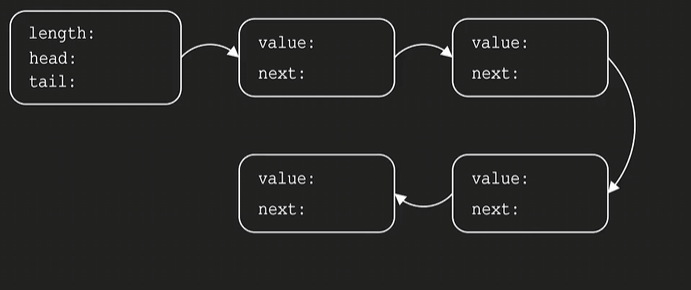

To better understand how Linked Lists work .Let's imagine our computer's memory right here to the right. Let's now assume that our links list object is stored in these three memory slots (0x0048,4C,50)

The first of those is occupied by the length of the list. And at address number 4C, we might have the head of the list. At this point, it's time to better define a word that we have been using a lot and that is the pointer.

We keep saying that this node points to this node and the head points to that node and so on. But what does that even mean? Well, you can think of a pointer as being a number that represents one of these memory addresses. So when we say that the head of the list is equal to a certain node or points to a certain node, what I actually mean is that in the section where our linked list object is stored, the value of the head attribute will be the memory location of our first node, let's say at number 74.

So when we access the head attribute, we get whatever is stored in location 74, which in our case will be a different object, this time a node object, and it too will have some information stored in it, like the value which will be whatever we want it to be, and the next attribute. And guess what this next attribute will be? You guessed it. It will also be a memory location of another node. And the thing is, it doesn't have to be the next one right after it. The next node can be located, let's say at section 58.And there we will find again a node object with some data and the location of the next node, and so on. And the last node, as we learned, will point to none.

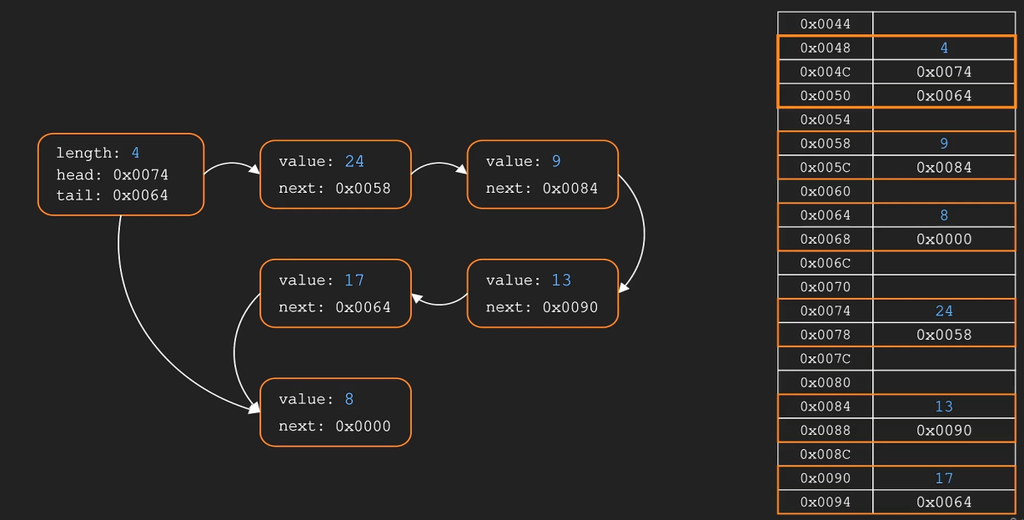

What does that mean in terms of memory address? Basically the same as the previous nodes. The none value also has to be stored in our computer's memory somewhere. Let's say it will be at address 0000.At this point if we found the last node. This means that the tail property of the linked list will also need to point to this node. Therefore, in the memory block where our list object is stored, the last allocated address will contain the location of this node.

Hopefully right now you can see clearer what all these operations meant when we needed to traverse the list.By going from one node to another, we just access the memory location indicated by the next property of each node object. When we needed to append an item to the end of the list, we first created a new node object. Our computer then placed it in some memory address that was available at that moment. We then navigated to the tail location straight from the address stored in the list object .We changed the address of what it was pointing to from none to the address of the new node. And finally updated the tail attribute in the list object to reference the new address

### Table of Complexity Comparison - Array vs Singly Linked List

The first two are adding and removing from the start of the classic array. Both these operations need O(n) time to run, because if you remember, we need to reassign all the following elements to different indices. Adding and removing from the end will run in constant time, with the mention that sometimes adding to the end will require the entire array to be copied to another memory location, and in that case the runtime will be O(n), but since that happens very rarely with large arrays, the generally accepted complexity is O(1). Searching will be O(n) time, since you could potentially run over all the elements of the list until you find the one you're looking for. And such iteration will require linear time & access. This is done instantly in a normal array because it is indexed, and we can get the element at any position just by referencing its index.

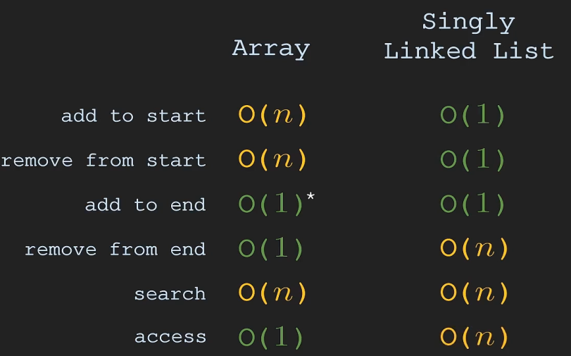

If we now look at the singly linked list. The first two operations, unlike the classic array, are both simple functions. No re-indexing is required for the linked list. Both run in constant time. Adding to the end is also constant time, because we have a direct pointer to the tail node, and all we need to do is attach it to the last node. Removing from the end, on the other hand, is done in O(n) time. Since we're forced to go over all the nodes to reach the second to last node and then cut the link to the last node. Searching is also anO(n) operation, just like the normal array.

If we want to find an element with a specific value, we don't really have a choice other than checking them one by one. Lastly, unlike the classic array in the linked list, access is done in linear time. If we want to know the value of the 50th node, for example, we don't have direct access to it like we do with indices, so we'll have to traverse one node at a time until we reach it.

### Real-Life Applications of Linked Lists

#### Singly Linked List (SLL)

- **Dynamic Memory Management**
  - Used in operating systems to manage free memory blocks.
  - Efficient allocation/deallocation without requiring contiguous memory.
- **Stacks & Queues**
  - Natural fit for implementing stacks (LIFO) and queues (FIFO).
  - Examples: Job scheduling in OS, printer queues.
- **Polynomial Arithmetic & Large Numbers**
  - Represent polynomials or very large integers where each node stores a coefficient/digit.
  - Useful in scientific computing and cryptography.
- **File Systems & Symbol Tables**
  - Directory structures and symbol tables in compilers often use linked lists.
- **Sparse Matrices**
  - Efficient representation of sparse data (lots of zeros) in scientific applications.

### Comparison Table

| Use Case | Singly Linked List | Doubly Linked List |
| --- | --- | --- |
| Memory management | ✅ | ❌ |
| Stacks/Queues | ✅ | ❌ |
| Browser navigation | ❌ | ✅ |
| Music/Video playlists | ❌ | ✅ |
| Undo/Redo in editors | ❌ | ✅ |
| Sparse matrices | ✅ | ❌ |
| LRU Cache | ❌ | ✅ |

#### Key Takeaways

- **SLL** → lightweight, forward-only traversal, good for queues, stacks, memory blocks.
- **DLL** → heavier (extra pointer per node), but supports bidirectional traversal and faster deletions.
- Choice depends on whether you need **simplicity & memory efficiency** (SLL) or **flexibility & bidirectional navigation** (DLL).